# Valuation Model

Nicholas Kondo, Luke G, Darron K

# Introduction

For this study, data was collected from FBref.com on the “Big 5” Leagues. Our data includes statistics in categories such as standard, shooting, passing, goal and shot creation, defense, miscellaneous, playing time, and market values. We compare a player’s statistics with their market values listed on TransferMarkt.com and find the statistics that are most correlated with a player’s market values. In other words, we are aiming to find the certain statistics that makes a player valuable.

We are going to filer the players by position. Here are the different positions listed on Transfermarkt and the number of players at the respective position.

```r
table(market_values$player_position)
```

```
##
##             attack Attacking Midfield   Central Midfield
##                  1                628               1541
##        Centre-Back     Centre-Forward            defence
##               1938               1532                  2
## Defensive Midfield         Goalkeeper      Left Midfield
##                868               1244                106
##        Left Winger          Left-Back           midfield
##                666                840                  5
##     Right Midfield       Right Winger         Right-Back
##                 60                710                868
##     Second Striker
##                133
```

Notice that there are some ‘strange’ values at some positions. Specifically:

`attack` : 1 player

`midfield`: 5 players

`defence`: 2 players

```r
strange <- market_values %>%
    select(player_name, comp_name, player_position, current_club, player_market_value_euro,
        player_age) %>%
    filter(player_position == "midfield" | player_position == "attack" |
        player_position == "defence")

head(strange, 8)
```

```
##        player_name      comp_name player_position     current_club
## 1            Verza         LaLiga        midfield     Without Club
## 2           Renato        Serie A         defence   Ventforet Kofu
## 3    Samuel Robert        Ligue 1          attack  Racing Besançon
## 4 Federico Chiossi        Serie A        midfield Real Calepina FC
## 5      Jawad Dramé        Ligue 1        midfield       OGC Nice B
## 6   Mathurin Sakho        Ligue 1         defence         US Camon
## 7      Théo Godard        Ligue 1        midfield     Without Club
## 8     Andi Janjeva Premier League        midfield   Watford FC U23
##   player_market_value_euro player_age
## 1                   600000         31
## 2                       NA         20
## 3                       NA         20
## 4                    50000         20
## 5                       NA         19
## 6                       NA         24
## 7                       NA         18
## 8                       NA         17
```

Are these players we can remove? Non-relevant players? Most players we don’t have a valuation for anyway.

**Joining Data Sets**

We created a unique identifier for each table and now it’s time to filter our positions and pull data from the relevant tables to that position. Here are the tables we will use for each position:

1: `keepers`, `keepers_adv`, `playingtime`, `standard`, `market_values`

2-5: `defense`, `possession`, `playingtime`, `passing`, `passingtypes`, `standard`, `market_values`

7-11: `standard`, `shooting`, `gca`, `passing`, `passingtypes`, `possession`, `playingtime`, `market_values`

# Attacking

### Random Forest

```r
# Creating a table to remove all the factor variables with more than
# 40 factors Filtering out positions 7 - 11

# All Variables

Attacking2 <- Attacking1 %>%
    select(-region, -PlayerYearComp_id, -Url, -Season_End_Year, -Squad,
        -Player, -Nation, -Pos, -Age, -Born, -player_dob, -player_name,
        -player_num, -squad, -country, -comp_name, -player_nationality,
        -current_club, -player_height_mtrs, -date_joined, -joined_from,
        -contract_expiry, -player_url) %>%
    filter(player_position == "Right Winger" | player_position == "Central Midfield" |
        player_position == "Centre-Forward" | player_position == "Left Winger" |
        player_position == "Attacking Midfield")

RF_Attacking <- randomForest(player_market_value_euro ~ ., data = Attacking2,
    type = regression, mtry = 5, na.action = na.roughfix, ntree = 1000)
print(RF_Attacking)
```

```
##
## Call:
##  randomForest(formula = player_market_value_euro ~ ., data = Attacking2,      type = regression, mtry = 5, ntree = 1000, na.action = na.roughfix)
##                Type of random forest: regression
##                      Number of trees: 1000
## No. of variables tried at each split: 5
##
##           Mean of squared residuals: 13073704965086
##                     % Var explained: 94.65
```

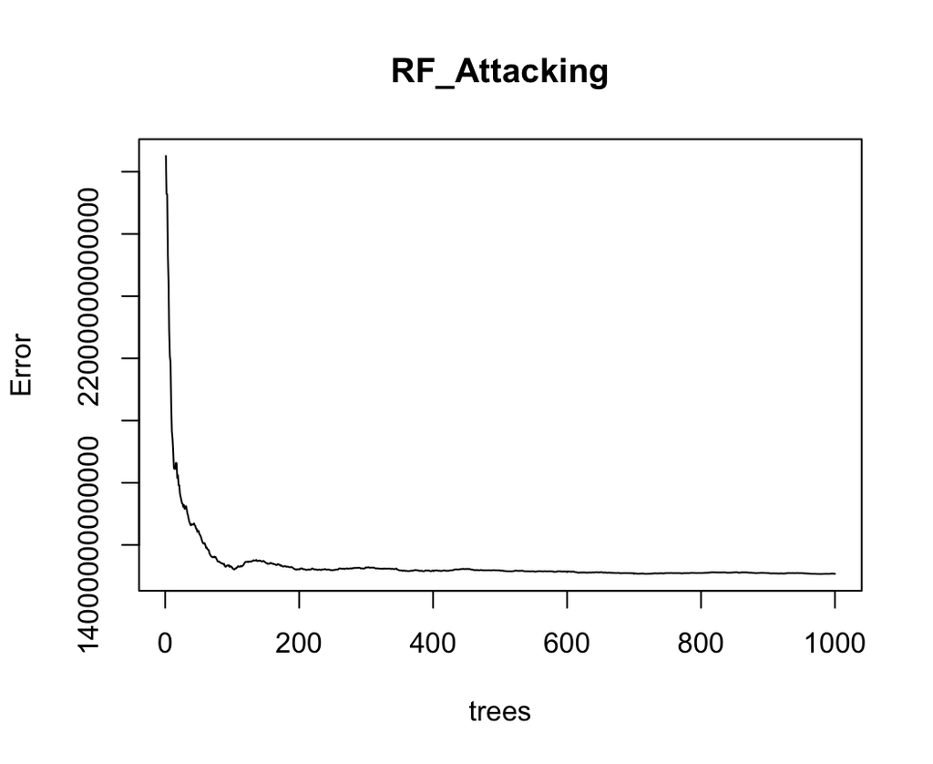

```r
plot(RF_Attacking)
```

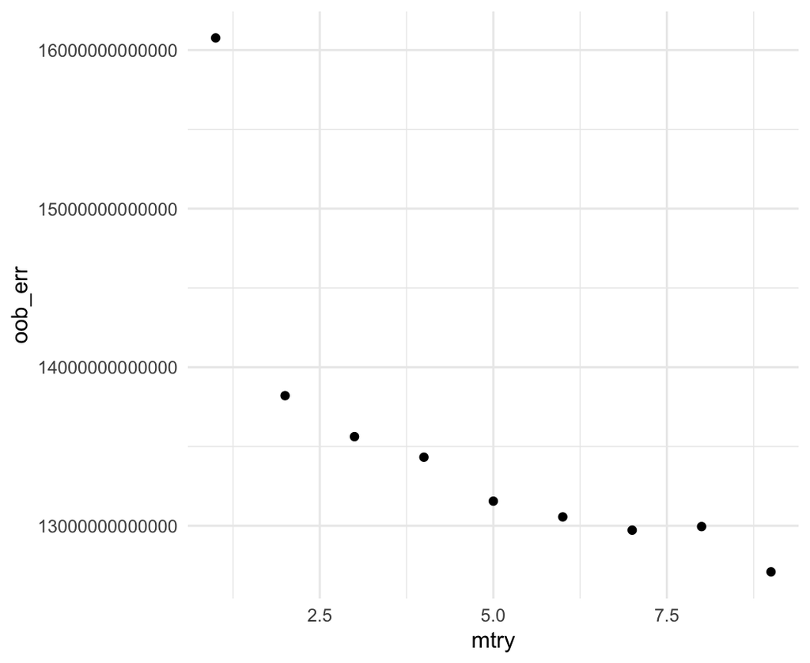

```r
# All Variables
rf_mods <- list()
oob_err <- NULL
test_err <- NULL
for (mtry in 1:9) {
    rf_fit_attacking <- randomForest(player_market_value_euro ~ ., data = Attacking2,
        mtry = mtry, na.action = na.roughfix, ntree = 600)
    oob_err[mtry] <- rf_fit_attacking$mse[600]

    cat(mtry, " ")
}
## 1  2  3  4  5  6  7  8  9
## 1 2 3 4 5 6 7 8 9
results_DF <- data.frame(mtry = 1:9, oob_err)
ggplot(results_DF, aes(x = mtry, y = oob_err)) + geom_point() + theme_minimal() +
    xlim(1, 9)
```

### Variable Importance Plot

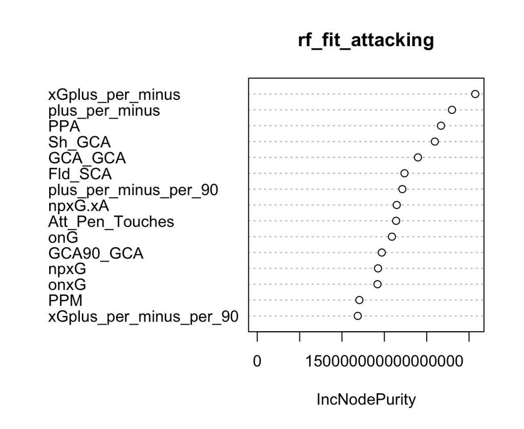

```r
varImpPlot(rf_fit_attacking, n.var = 15)
```

**Important Variables**

`GCA`: Goal Creating Actions

`PPA`: Completed passes into the 18 yard box

`xG +/-` : Expected Goals Scored minus Expected Goals Allowed

### Linear Regression

```r
Attacking_LinReg <- lm(player_market_value_euro ~ GCA_GCA + PPA + xGplus_per_minus,
    data = Attacking2)

summary(Attacking_LinReg)
```

```
##
## Call:
## lm(formula = player_market_value_euro ~ GCA_GCA + PPA + xGplus_per_minus,
##     data = Attacking2)
##
## Residuals:
##       Min        1Q    Median        3Q       Max
## -82954205  -5073243  -1736311   3530505 114404197
##
## Coefficients:
##                  Estimate Std. Error t value            Pr(>|t|)
## (Intercept)       4730371      97862   48.34 <0.0000000000000002 ***
## GCA_GCA           1164231      28351   41.06 <0.0000000000000002 ***
## PPA                344709       8396   41.06 <0.0000000000000002 ***
## xGplus_per_minus  1102052      14200   77.61 <0.0000000000000002 ***
## ---
## Signif. codes:  0 '***' 0.001 '**' 0.01 '*' 0.05 '.' 0.1 ' ' 1
##
## Residual standard error: 11930000 on 25964 degrees of freedom
##   (292 observations deleted due to missingness)
## Multiple R-squared:  0.4232, Adjusted R-squared:  0.4231
## F-statistic:  6349 on 3 and 25964 DF,  p-value: < 0.00000000000000022
```

### Interpretation

The linear model has an adjusted R square of .42

For every goal creating action, a player’s market value is usually 1.1 million euros higher.

For every completed pass in the 18 yard box, a player’s market value us usually 300K euros higher.

For every 1 point increase in xG +/-, a player’s salary is typically 1.1 million euros higher.

# Defenders

We removed defensive midfield from this group of defenders.

### Random Forest

```r
# Creating a table to remove all the factor variables with more than
# 40 factors Filtering out positions 2 - 6

# All Variables

Defenders2 <- Defenders1 %>%
    select(-region, -PlayerYearComp_id, -Url, -Season_End_Year, -Squad,
        -Player, -Nation, -Pos, -Age, -Born, -player_dob, -player_name,
        -player_num, -squad, -country, -comp_name, -player_nationality,
        -current_club, -player_height_mtrs, -date_joined, -joined_from,
        -contract_expiry, -player_url) %>%
    filter(player_position == "Right-Back" | player_position == "Left-Back" |
        player_position == "Centre-Back")

RF_defending <- randomForest(player_market_value_euro ~ ., data = Defenders2,
    type = regression, mtry = 5, na.action = na.roughfix, ntree = 1500)
print(RF_defending)
```

```
##
## Call:
##  randomForest(formula = player_market_value_euro ~ ., data = Defenders2,      type = regression, mtry = 5, ntree = 1500, na.action = na.roughfix)
##                Type of random forest: regression
##                      Number of trees: 1500
## No. of variables tried at each split: 5
##
##           Mean of squared residuals: 13960644326955
##                     % Var explained: 83.34
```

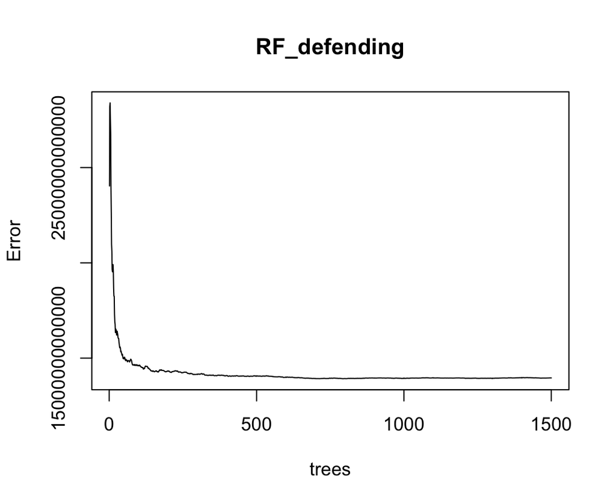

```r
plot(RF_defending)
```

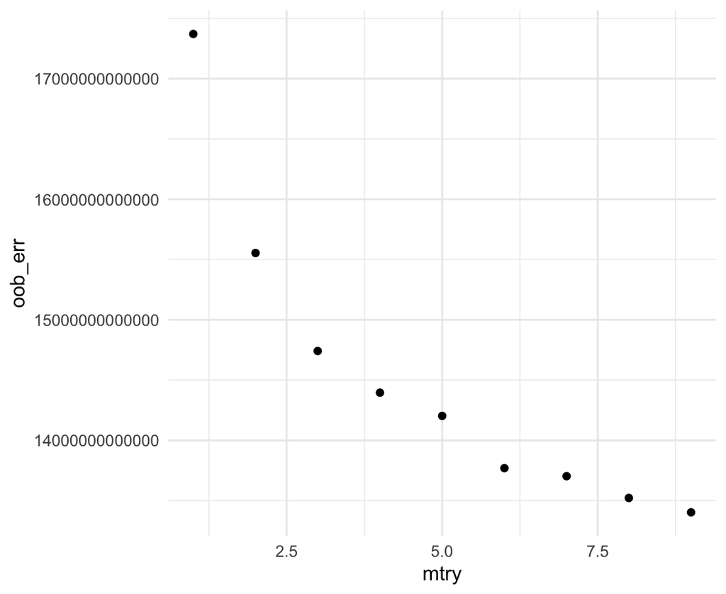

```r
# All Variables
rf_mods <- list()
oob_err <- NULL
test_err <- NULL
for (mtry in 1:9) {
    rf_fit_defending <- randomForest(player_market_value_euro ~ ., data = Defenders2,
        mtry = mtry, na.action = na.roughfix, ntree = 600)
    oob_err[mtry] <- rf_fit_defending$mse[600]

    cat(mtry, " ")
}
## 1  2  3  4  5  6  7  8  9
## 1 2 3 4 5 6 7 8 9
results_DF <- data.frame(mtry = 1:9, oob_err)
ggplot(results_DF, aes(x = mtry, y = oob_err)) + geom_point() + theme_minimal() +
    xlim(1, 9)
```

### Variable Importance Plot

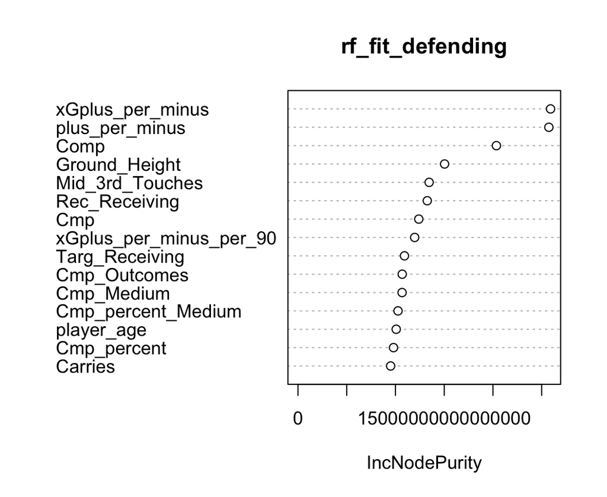

```r
varImpPlot(rf_fit_defending, n.var = 15)
```

**Important Variables**

`xG +/-`: Expected Goals minus expected goals allowed while on the pitch

`Comp`: League the player is in

`Ground_Height` : Number of ground passes

### Linear Regression

```r
Defending_LinReg <- lm(player_market_value_euro ~ xGplus_per_minus + Comp +
    Ground_Height + TotDist, data = Defenders2)

summary(Defending_LinReg)
```

```
##
## Call:
## lm(formula = player_market_value_euro ~ xGplus_per_minus + Comp +
##     Ground_Height + TotDist, data = Defenders2)
##
## Residuals:
##       Min        1Q    Median        3Q       Max
## -28840311  -2960748   -709210   2263532  57484100
##
## Coefficients:
##                      Estimate Std. Error t value             Pr(>|t|)
## (Intercept)         2537808.9   195978.2  12.949 < 0.0000000000000002
## xGplus_per_minus     397715.2    11549.5  34.436 < 0.0000000000000002
## CompLigue 1        -2190250.6   258874.2  -8.461 < 0.0000000000000002
## CompPremier League  6842963.2   239530.5  28.568 < 0.0000000000000002
## CompSerie A        -1352103.1   209266.8  -6.461       0.000000000111
## Ground_Height          6534.4      510.4  12.803 < 0.0000000000000002
## TotDist                 216.4       19.8  10.928 < 0.0000000000000002
##
## (Intercept)        ***
## xGplus_per_minus   ***
## CompLigue 1        ***
## CompPremier League ***
## CompSerie A        ***
## Ground_Height      ***
## TotDist            ***
## ---
## Signif. codes:  0 '***' 0.001 '**' 0.01 '*' 0.05 '.' 0.1 ' ' 1
##
## Residual standard error: 6454000 on 7094 degrees of freedom
##   (65 observations deleted due to missingness)
## Multiple R-squared:  0.5073, Adjusted R-squared:  0.5068
## F-statistic:  1217 on 6 and 7094 DF,  p-value: < 0.00000000000000022
```

We have an adjusted R Square of .50.

# Goalkeeper

## Random Forest

```r
# Creating a table to remove all the factor variables with more than
# 40 factors Filtering out positions 2 - 6

# All Variables

Goalkeepers2 <- Goalkeepers1 %>%
    select(-region, -PlayerYearComp_id, -Url, -Season_End_Year, -Squad,
        -Player, -Nation, -Pos, -Age, -Born, -player_dob, -player_name,
        -player_num, -squad, -country, -comp_name, -player_nationality,
        -current_club, -player_height_mtrs, -date_joined, -joined_from,
        -contract_expiry, -player_url) %>%
    filter(player_position == "Goalkeeper")

RF_Goalkeepers <- randomForest(player_market_value_euro ~ ., data = Goalkeepers2,
    type = regression, mtry = 4, na.action = na.roughfix, ntree = 1500)
print(RF_Goalkeepers)
```

```
##
## Call:
##  randomForest(formula = player_market_value_euro ~ ., data = Goalkeepers2,      type = regression, mtry = 4, ntree = 1500, na.action = na.roughfix)
##                Type of random forest: regression
##                      Number of trees: 1500
## No. of variables tried at each split: 4
##
##           Mean of squared residuals: 48368641182900
##                     % Var explained: 57.21
```

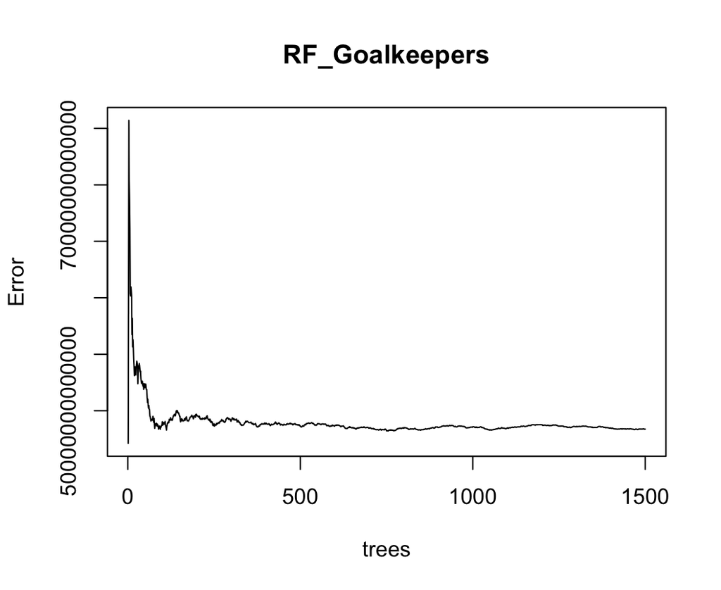

```r
plot(RF_Goalkeepers)
```

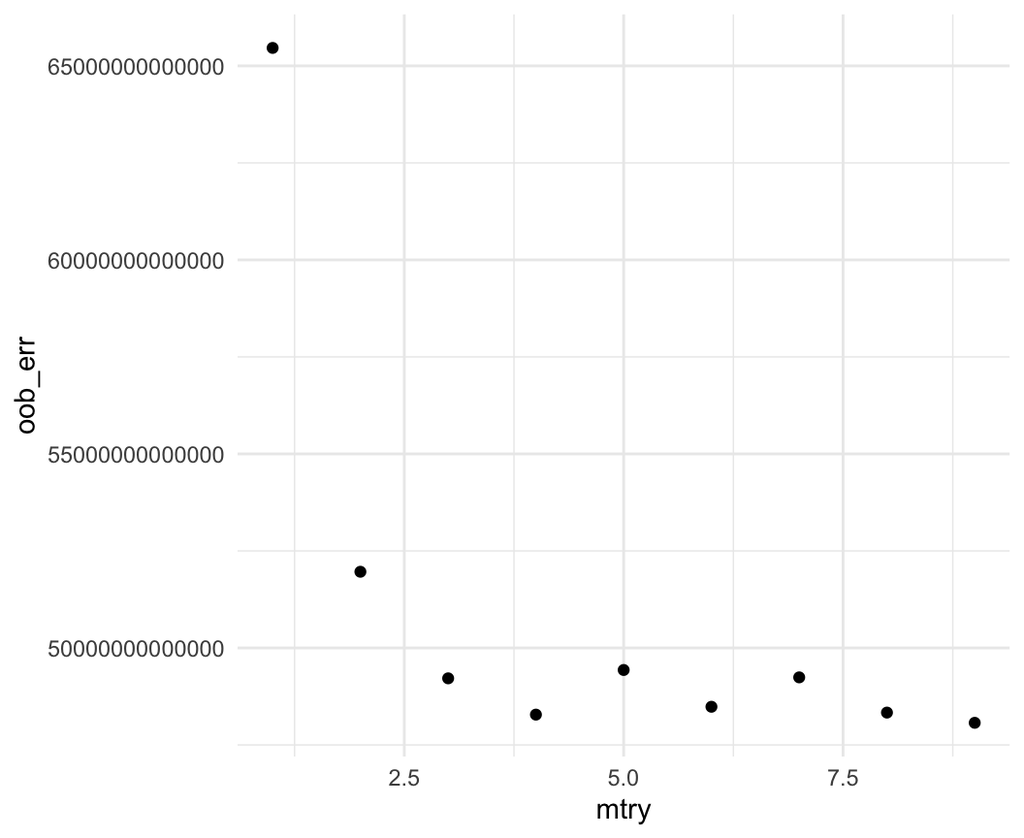

```r
# All Variables
rf_mods <- list()
oob_err <- NULL
test_err <- NULL
for (mtry in 1:9) {
    rf_fit_goalkeeping <- randomForest(player_market_value_euro ~ ., data = Goalkeepers2,
        mtry = mtry, na.action = na.roughfix, ntree = 600)
    oob_err[mtry] <- rf_fit_goalkeeping$mse[600]

    cat(mtry, " ")
}
## 1  2  3  4  5  6  7  8  9
## 1 2 3 4 5 6 7 8 9
results_DF <- data.frame(mtry = 1:9, oob_err)
ggplot(results_DF, aes(x = mtry, y = oob_err)) + geom_point() + theme_minimal() +
    xlim(1, 9)
```

## Variable Importance Plot

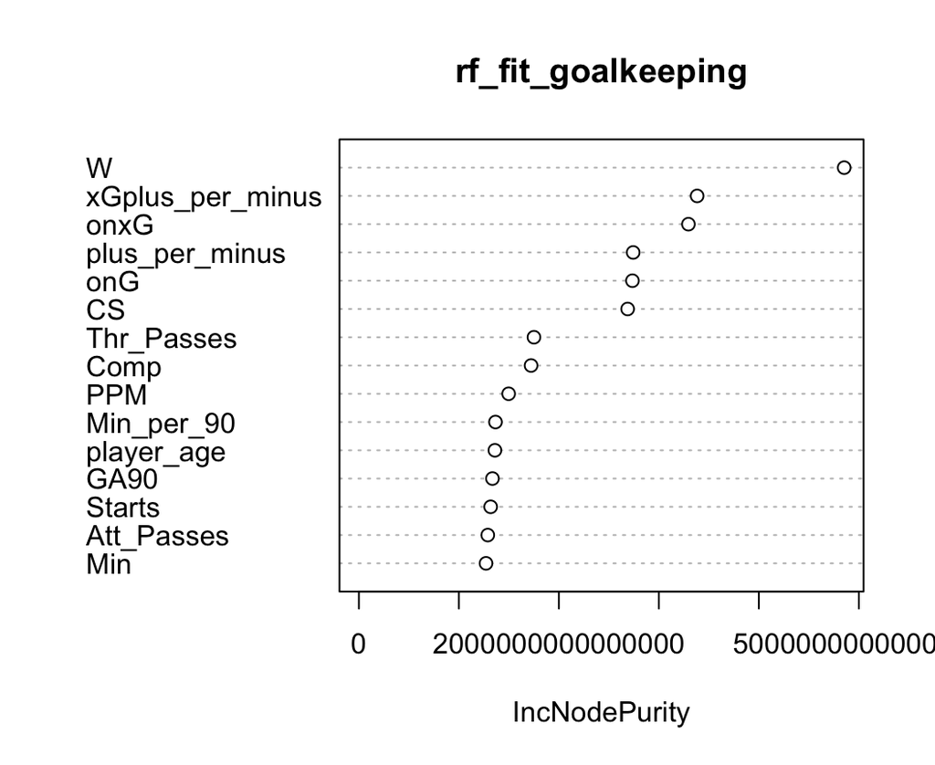

```r
varImpPlot(rf_fit_goalkeeping, n.var = 15)
```

**Important Variables**

`W`: Wins

`plus_per_minus`: Goals scored minus goals allowed

`onxG:` Goals created while on the pitch

`CS`: Clean Sheets

## Linear Regression

```r
Goalkeepers_linreg <- lm(player_market_value_euro ~ plus_per_minus + CS +
    W, data = Goalkeepers2)

summary(Goalkeepers_linreg)
```

```
##
## Call:
## lm(formula = player_market_value_euro ~ plus_per_minus + CS +
##     W, data = Goalkeepers2)
##
## Residuals:
##       Min        1Q    Median        3Q       Max
## -31848985  -3416786    -85041   1406780  45255922
##
## Coefficients:
##                Estimate Std. Error t value      Pr(>|t|)
## (Intercept)      159205     520207   0.306       0.75969
## plus_per_minus    85125      27242   3.125       0.00188 **
## CS                81670     206641   0.395       0.69283
## W                969061     161099   6.015 0.00000000332 ***
## ---
## Signif. codes:  0 '***' 0.001 '**' 0.01 '*' 0.05 '.' 0.1 ' ' 1
##
## Residual standard error: 7804000 on 539 degrees of freedom
##   (3 observations deleted due to missingness)
## Multiple R-squared:  0.4679, Adjusted R-squared:  0.4649
## F-statistic:   158 on 3 and 539 DF,  p-value: < 0.00000000000000022
```

## Interpretation

The adjusted R Square is .46.

For every +/- point, a goal keepers salary is typically 85K more Euros.

For every additional clean sheet, a goalie typically gets paid 82K higher.

# Appendix

### Standard

`Season_End_Year`: The year at the end of the season.

`Squad`: The team the player plays on.

`Comp`: The league the player plays in.

`Player`: The name of the player.

`Nation`: Nationality of the Player.

`Pos`: The player’s position

`Age`: Current Age

`Born`: Year of Birth

`Matches_Played`: Matches Played

`Starts`: Games Started

`Min`: Minutes Played

`Min_per_90`: Minutes Played divided by 90

`Gls`: Goals

`Ast`: Assists

`G_minus_PK`: Goals minus Penalty Kicks

`PK`: Penalty Kicks Made

`PKatt`: Penalty Kicks Attempted

`CrdY`: Yellow cards

`CrdR`: Red Cards

`Gls_Per`: Goals Scored per 90 minutes

`Ast_Per`: Assists per 90 minutes

`G+A_Per`: Goals and Assists per 90 minutes

`G_minus_PK_Per`: Goals minus Penalty Kicks per 90 minutes

`G+A_minus_PK_Per`: Goals and Assists minus Penalty Kicks per 90 minutes

`xG`: Expected Goals

`npxG`: Non-Penalty Expected Goals

`xA`: xG Assisted

`npxG+xA`: Non Penalty Expected Goals plus xG Assisted

`xG_Per`: Expected Goals per 90 minutes

`xA_Per`: xG Assisted per 90 minutes

`xG+xA_Per`: Expected Goals plus Assist per 90 minutes

`npxG_Per`: Non-Penalty Expected Goals per 90 minutes

`npxG+xA_Per`: Non-Penalty Expected Goals plus xG Assisted per 90 minutes

### Goalkeeping - Luke

`Season_End_Year`: The year at the end of the season.

`Squad`: The team the player plays on.

`Comp`: The league the player plays in.

`Player`: The name of the player.

`Nation`: Nationality of the Player.

`Pos`: The player’s position

`Age`: Current Age

`Born`: Year of Birth

`Matches_Played`: Matches Played

`Starts`: Games Started

`Min`: Minutes Played

`Min_per_90`: Minutes Played divided by 90 (Number of games)

`GA`: Goals scored against

`GA90`: Goals scored against per 90 minutes

`SoTA`: Shots on Target Against

`Saves`: Number of saves

`Save_percent`: (Shots on Target Against - Goals Against) / Shots on Target Against *Note that not all shots on target are stopped by the keeper, many will be stopped by defenders. Does not include penalty kicks*

`W`: Wins

`D`: Draws

`L`: Losses

`CS`: Clean sheets (When no goals are scored against)

`CS_percent`: Percentage of matches resulting in clean sheets

`PKatt_Penalty`: Penalty kicks attempted

`PKA_Penalty`: Penalty kicks allowed in

`PKsv_Penalty`:Penalty kicks saved

`PKm_Penalty`: Penalty kicks missed by opposing team

`Save_percent_Penalty`: Penalty Kick Goals Against/Penalty Kick Attempts *Penalty shots that miss the target are not included*

### Advanced Goalkeeping - Luke

`Season_End_Year`: The year at the end of the season.

`Squad`: The team the player plays on.

`Comp`: The league the player plays in.

`Player`: The name of the player.

`Nation`: Nationality of the Player.

`Pos`: The player’s position

`Age`: Current Age

`Born`: Year of Birth

`Min_per_90`: Minutes Played divided by 90 (Number of games)

`GA`: Goals scored against

`PKA`: Penalty Kicks Allowed

`FK`: Free Kick Goals Against

`CK`: Corner Kick Goals Against

`OG`: Own Goals Scored Against Keeper

`PSxG`: Post-shot expected goal; based on how likely the goalkeeper is to save the shot. (In-game penalty kicks included)

`PSxG_per_SoT`: Post-shot expected goals per shot on target. (Penalty kicks not included)

`PSxG_plus_minus`: Post-Shot Expected Goals minus Goals Allowed (Positive numbers suggest better luck or an above average ability to stop shots)

`per_90`: Post-Shot Expected Goals minus Goals Allowed per 90 minutes

`Cmp_Launched`: Passes longer than 40 yards completed

`Att_Launched`: Passes longer than 40 yards attempted

`Cmp_percent_Launched`: 40+ yard pass completion rate

`Att_Passes`: Attempted passes excluding goal kicks

`Thr_Passes`: Throws attempted

`Launch_percent_Passes`: Percentage of Passes that were Launched and not Goal Kicks

`AvgLen_Passes`: Average Length of Passes in Yards

`Att_Goal`: Goal Kicks Attempted

`Launch_percent_Goal`: Percentage of Goal Kicks sent more than 40 yards

`AvgLen_Goal`: Average length of goal kicks

`Opp_Crosses`: Opponents attempted crosses into penalty area

`Stp_percent_Crosses`: Percent of crosses into penalty area which were successfully stopped by the goalkeeper

`#OPA_Sweeper`: Number of defensive actions outside of penalty area

`#OPA_per_90_Sweeper`: Defensive actions outside of penalty area per 90 minutes

`AvgDist_Sweeper`: Average distance from goal (in yards) of all defensive actions

### Shooting

`Season_End_Year`: The year at the end of the season.

`Squad`: The team the player plays on.

`Player`: The name of the player.

`Nation`: Nationality of the Player.

`Pos`: The player’s position

`Age`: Current Age

`Born`: Year of Birth

`Mins_per_90`: Minutes played divided by 90

`Gls`: Goals scored or allowed

`SH`: Shots Total

`SoT`: Shots on target

`SoT_percent`: Shots on target percentage, percentage of shots that are on target

`Sh_per_90`: Shots total per 90 minutes

`Sot_per_90`: Shots on target per 90 minutes

`G_per_Sh`: Goals per shot

`G_per_SoT`: Goals per shot on target

`Dist`: Average distance, in yards, from goal of all shots taken

`FK`: Shots from free kicks

`PK`: Penalty Kicks Made

`PKatt`: Penalty Kicks Attempted

`xG`: Expected Goals

`npxG`: Non-Penalty Expected Goals

`npxG_per_Sh`: Non-Penalty Expected Goals per shot

`G_minus_xG`: Goals minus Expected Goals

`npG_minus_npxG`: Non-Penalty Goals minus Non-Penalty Expected Goals

### Passing - Luke

`Season_End_Year`: The year at the end of the season

`Squad`: The team the player plays on

`Comp`: The league the player plays in

`Player`: The name of the player

`Nation`: Nationality of the Player

`Pos`: The player’s position

`Age`: Current Age

`Born`: Year of Birth

`Mins_per_90`: Minutes played divided by 90

`Cmp`: Passes Completed

`Cmp_percent`: Pass completion percentage

`TotDist`: Total distance of completed passes in yards

`PrgDist`: Total distance, in yards, that completed passes have traveled towards the opponent’s goal

`Cmp_short`: Completed passes within 5 and 15 yards

`Att_short`: Attempted passes within 5 to 15 yards

`Cmp_percent_Short`: Completion percentage of passes within 5 to 15 yards

`Cmp_Medium`: Completed passes within 15 to 30 yards

`Att_Medium`:Attempted passes within 15 to 30 yards

`Cmp_percent_Medium`: Completion percentage of passes within 15 to 30 yards

`Cmp_Long`: Completed passes over 30 yards

`Att_Long`: Attempted passes over 30 yards

`Cmp_percent_Long`: Completion percentage of passes over 30 yards

`Ast`: Assists

`xA`: Expected Assists

`A_minus_xA`: Assists minus xA

`KP`: Passes directly leading to a shot

`Final_Third`: Completed passes that enter the 1/3 of the pitch closest to the goal

`PPA`: Completed passes into the 18-yard box

`CrsPA`: Completed crosses into the 18-yard box

`Prog`: Completed passes moving the ball towards the opponent’s goal at least 10 yards from its furthest point in the last six passes, or any completed pass into the penalty area

### Pass Types - Luke

`Season_End_Year`: The year at the end of the season.

`Squad`: The team the player plays on.

`Comp`: The league the player plays in.

`Player`: The name of the player.

`Nation`: Nationality of the Player.

`Pos`: The player’s position

`Age`: Current Age

`Born`: Year of Birth

`Mins_Per_90`: Minutes played divided by 90

`Att`: Passes Attempted

`Live_Pass`: Live-ball passes

`Dead_Pass`: Dead-ball passes such as a free kick or corner kick

`FK_Pass`: Passes attempted from freekicks

`TB_Pass`: Completed pass sent between back defenders into open space

`Press_Pass`: Passes made while under pressure from opponent

`Sw_Pass`: Passes that travel more than 40 yards of the width of the pitch

`Crs_Pass`: Crosses

`CK_Pass`: Corner Kicks

`In_Corner`: Inswinging Corner Kicks

`Out_Corner`: Outswinging Corner Kicks

`Str_Corner`: Straight Corner Kicks

`Ground_Height`: Ground passes

`Low_Height`: Passes below shoulder-level

`High_Height`: Passes above shoulder-level

`Left_Body`: Passes attempted using left foot

`Right_Body`: Passes attempted using right foot

`Head_Body`: Passes attempted using head

`TI_Body`: Throw-ins Taken

`Other_Body`: Passes attempted using body parts other than the player’s head or feet

`Cmp_Outcomes`: Passes completed

`Off_Outcomes`: Offsides

`Out_Outcomes`: Out of bounds

`In_Outcomes`: Intercepted

`Blocks_Outcomes`: Blocked by an opponent

### Goal and Shot Creation

`Season_End_Year`: The year at the end of the season.

`Squad`: The team the player plays on.

`Comp`: The league the player plays in.

`Player`: The name of the player.

`Nation`: Nationality of the Player.

`Pos`: The player’s position

`Age`: Current Age

`Born`: Year of Birth

`Mins_Per_90`: Minutes played divided by 90

`SCA_SCA`: Shot-creating Actions

`SCA90__SCA`: Shot-creating Actions per 90 minutes

`PassLive_SCA`: Completed live-ball passes that lead to a shot attempt

`PassDead_SCA`: Completed dead-ball passes that lead to a shot attempt (Includes free kicks, corner kicks, kick offs, throw-ins and goal kicks)

`Drib_SCA`: Successful dribbles that lead to a shot attempt

`Sh_SCA`: Shots that lead to another shot attempt

`Fld_SCA`: Fouls drawn that lead to a shot attempt

`Def_SCA`: Defensive actions that lead to a shot attempt

`GCA_GCA`: The offensive actions directly leading to a goal, such as passes, dribbles and drawing fouls

`GCA90_GCA`: Goal-Creating Actions per 90 minutes

`PassLive_GCA`: Completed live-ball passes that lead to a goal

`PassDead_GCA`: Completed dead-ball passes that lead to a goal (Includes free kicks, corner kicks, kick offs, throw-ins and goal kicks)

`Drib_GCA`: Successful dribbles that lead to a goal

`Sh_GCA`: Shots that lead to another goal-scoring shot

`Fld_GCA`: Fouls drawn that lead to a goal

`Def_GCA`: Defensive actions that lead to a goal

### Defensive Actions

`Season_End_Year`: The year at the end of the season.

`Squad`: Team

`Player`: Players name

`Nation`: Players Nationality

`Pos`: Players position

`Age`: Current age

`Born`: Year of Birth

`Mins_Per_90`: Minutes played divided by 90

`Tkl`: Number of players tackled

`TklW`: Tackles in which the tackler’s team won possession of the ball

`Def_3rd`: Tackles in defensive 1/3

`Mid_3rd`: Tackles in middle 1/3

`Att_3rd`: Tackles in attacking 1/3

`Tkl_vs_dribble`: Number of dribblers tackled

`Att_vs_dribble`: Number of times dribbled past plus number of tackles

`Press_Pressures`: Number of times applying pressure to opposing player who is receiving, carrying or releasing the ball

`Succ_Pressures`: Number of times the squad gained possession withing five seconds of applying pressure

`Successful_Pressure_Percent`: Percentage of time the squad gained possession withing five seconds of applying pressure

`Def_3rd_Pressures`: Number of times applying pressure to opposing player who is receiving, carrying or releasing the ball, in the defensive 1/3

`Mid_3rd_Pressures`:Number of times applying pressure to opposing player who is receiving, carrying or releasing the ball, in the middle 1/3

`Att_3rd_Pressures`: Number of times applying pressure to opposing player who is receiving, carrying or releasing the ball, in the attacking 1/3

`Blocks`: Number of times blocking the ball by standing in its path

`Sh_Blocks`: Number of times blocking a shot by standing in its path

`ShSv_Blocks`: Number of times blocking a shot that was on target, by standing in its path

`Pass_Blocks`: Number of times blocking a pass by standing in its path

`Int`: Interceptions

`Tkl+Int`: Number of players tackled plus number of interceptions

`Clr`: Clearances

`Err`: Mistakes leading to an opponent’s shot

### Possessions

`Season_End_Year`: The year at the end of the season.

`Squad`: Team

`Player`: Players name

`Nation`: Players Nationality

`Pos`: Players position

`Age`: Current age

`Born`: Year of Birth

`Touches`: Number of times a player touched the ball

`Def_Pen`: Touches in defensive penalty area

`Def_3rd_Touches`: Touches in defensive 1/3

`Mid_3rd_Touches`: Touches in middle 1/3

`Att_3rd_Touches`: Touches in attacking 1/3

`Att_Pen_Touches`: Touches in attacking penalty area

`Live_Touches`: Live-ball touches

`Succ_Dribbles`: Dribbles Completed Successfully

`Att_Dribbles : Dribbles Attempted

`Succ_percent_Dribbles`: Percentage of Dribbles Completed Successfully

`#Pl_Dribbles`: Number of Players Dribbled Past

`Megs_Dribbles`: Number of times a player dribbled the ball through an opposing player’s legs

`Carries`: Number of times the player controlled the ball with their feet

`TotDist_Carries`: Total distance, in yards, a player moved the ball while controlling it with their feet, in any direction

`PrgDist_Carries`: Progressive Distance; Total distance, in yards, a player moved the ball while controlling it with their feet towards the opponent’s goal

`Prog_Carries`: Carries that move the ball towards the opponent’s goal at least 5 yards, or any carry into the penalty area

`Final_Third_Carries`: Carries that enter the 1/3 of the pitch closest to the goa

`CPA_Carries`: Carries into the 18-yard box

`Mis_Carries`: Number of times a player failed when attempting to gain control of a ball

`Dis_Carries`: Number of times a player loses control of the ball after being tackled by an opposing player

`Targ_Receiving`: Number of times a player was the target of an attempted pass

`Rec_Receiving`: Number of times a player successfully received a pass

`Rec_percent_Receiving`: Passes Received Percentage

`Prog_Receiving`: Progressive Passes Received

### Playing Time

`Season_End_Year`: The year at the end of the season.

`Squad`: The team the player plays on.

`Comp`: The league the player plays in.

`Player`: The name of the player.

`Nation`: Nationality of the Player.

`Pos`: The player’s position

`Age`: Current Age

`Born`: Year of Birth

`MP`: Matches Played

`Min`: Minutes

`Min_per_MP`: Minutes per Match Playerd

`Min_percent_Playing.Time`: Percentage of team’s total minutes in which player was on the pitch

`Mins_per_90`: Minutes played divided by 90

`Starts`: Game or games started by player

`Mn_per_Start`: Minutes Per Match Started

`Compl`: Complete matches played

`Subs`: Games as sub

`Mn_per_Sub`: Minutes Per Substitution

`unSub`: Games as an unused substitute

`PPM`: Points per Match

`onG`: Goals scored by team while on pitch

`onGA`: Goals allowed by team while on pitch

`plus_per_minus`: Goals scored minus goals allowed by the team while the player was on the pitch

`plus_per_minus_per_90`: Goals scored minus goals allowed by the team while the player was on the pitch per 90 minutes played

`On_minus_Off`:

`onxG`: Expected goals by team while on pitch

`onxGA`: Expected goals allowed by team while on pitch

`xGplus_per_minus`: Expected goals scored minus expected goals allowed by the team while the player was on the pitch

`xGplus_per_minus_per_90`: Expected goals scored minus expected goals allowed by the team while the player was on the pitch per 90 minutes played

### Misc

`Season_End_Year`: The year at the end of the season.

`Squad`: The team the player plays on.

`Comp`: The league the player plays in.

`Player`: The name of the player.

`Nation`: Nationality of the Player.

`Pos`: The player’s position

`Age`: Current Age

`Mins_Per_90`: Minutes played divided by 90

`CrdY`: Yellow cards

`2CrdY`: Second Yellow Card

`Fls`: Fouls committed

`Fld`: Fouls drawn

`Off`: Off-sides

`Crs`: Crosses

`Int`: Interceptions

`TklW`: Tackles in which the tackler’s team won possession of the ball

`PKwon`: Penalty Kicks Won

`PKcon`: Penalty Kicks Conceded

`OG`: Own Goals

`Recov`: Number of loose balls recovered

`Won_Aerial`: Aerials won

`Lost_Aerial`: Aerials lost

`Won_percent_Aerial`: Minimum .97 aerial duels per squad game to qualify as a leader

### Market Values Table

`squad`: The team the player plays on.

`player_name`: The player’s name

`player_url`: The player’s URL on transfermarkt

`player_position`: The player’s position

`player_age`: The player’s age

`player_name`: The player’s name

`player_nationality`: The player’s nationality

`current_club`: The club the player currently plays on

`player_height_mtrs`: The player’s height

`player_foot`: The player’s dominant foot

`joined_from`: The former club the player joined from

`contract_expiry`: The time when the player’s contract expires

`player_market_value_euro`: The valuation of the player in Euros

`date_joined`: The date the player joined